```python
import numpy as np
import pandas as pd
import matplotlib.pyplot as plt
import util as ut
import visuals as vs
```

# Load Dataset

Here we will pass the file paths to the load dataset function defined in util.py. This function takes files paths, load the files, renames columns merge all the files, splits the data into features and targets and reutrns features and targets

```python
# file paths for train set are saved in variables
file1 = "data/nifty50/niftytrain.csv"
file2 = "data/niftype/niftype.csv"
file3 = "data/niftyvix/niftyvix.csv"

# file paths for test set are saved in variables
testfile1 = "data/nifty50/niftytest.csv"
testfile2 = "data/niftype/niftypetest.csv"
testfile3 = "data/niftyvix/niftyvixtest.csv"

# Data is split into features and labels using Load_datset funtion defined
# in Utility folder. This function takes file paths, loads data, merge files
# splits and returns data into features and labels
features, prices = ut.load_dataset(file1,file2,file3,1)
features_test,prices_test = ut.load_dataset(testfile1,testfile2,testfile3,1)
print('Training Sample has {} data points with {} features each'.format(*features.shape))
print('Testing Sample has {} data points with {} features each'.format(*features_test.shape))
```

```
Training Sample has 1491 data points with 9 features each
Testing Sample has 200 data points with 9 features each
```

```
<function matplotlib.pyplot.show(*args, **kw)>
```

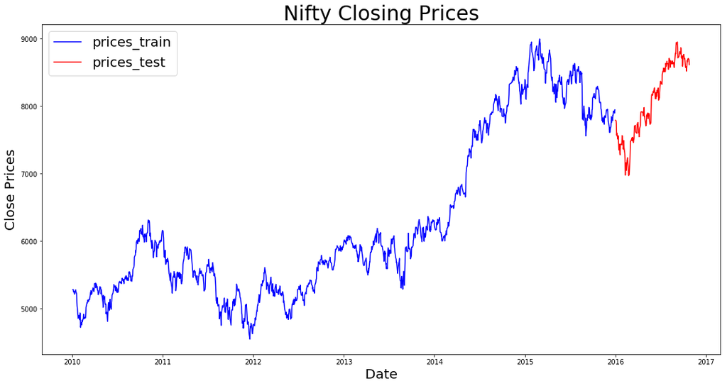

```python
# Plot Nifty50 closing prices
fig = plt.figure(figsize=(18,9))
plt.plot(prices,color='blue')
plt.plot(prices_test,color='red')
plt.xlabel('Date',fontsize=20)
plt.ylabel('Close Prices',fontsize=20)
plt.title('Nifty Closing Prices',fontsize=30)
plt.legend(["prices_train","prices_test"],fontsize=20)
plt.show
```

# Data Exploration

## Calculate Statistics

```python
# Calculate statistics of features and labels
#display(features.describe())
display(prices.describe())
```

```
count    1491.000000
mean     6277.683300
std      1219.052274
min      4544.200000
25%      5337.350000
50%      5870.100000
75%      7568.150000
max      8996.250000
Name: Close, dtype: float64
```

# Preparing the Data

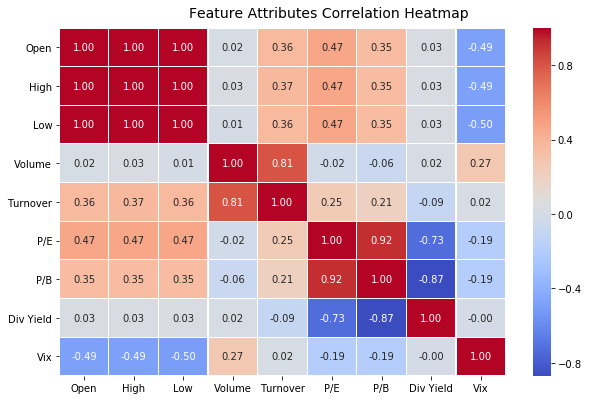

```python
# Check feature correlation using heatmap from seaborn
vs.heatmap(features)
```

As can be seen from above heatmap, there are few features which highly correlate and needs to be processed. For this we will add few features and new features

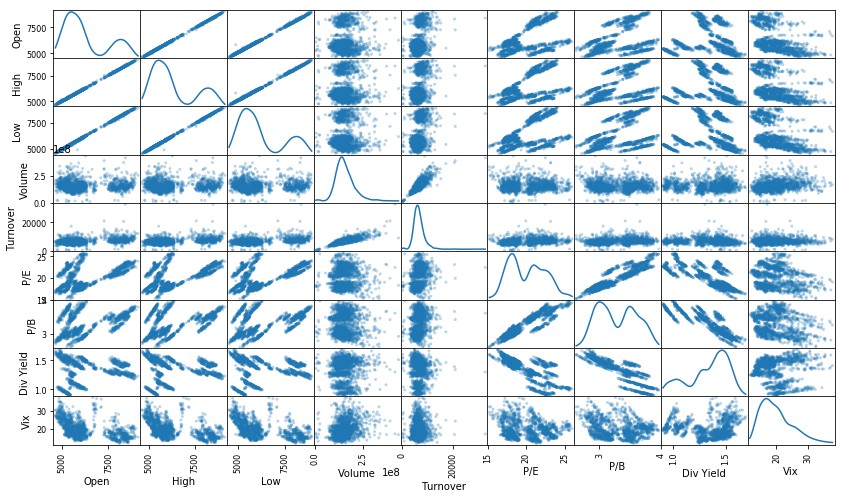

```python
#plot scatter plot of features to find correlation
pd.plotting.scatter_matrix(features, alpha = 0.3, figsize = (14,8), diagonal = 'kde');
```

# Feature Engineering

```python
# function for features addition using current featureset
def feature_addition(features):
    features['O-H'] = features['High']-features['Open']
    features['H-L'] = features['High'] - features['Low']
    features['O-L'] = features['Open'] - features['Low']
    return features

# Add new features using earlier features

features_train = feature_addition(features)
features_test = feature_addition(features_test)
```

```python
# Drop highly correlated features from our dataset

features_train = features_train.drop(['High','Low','Turnover','P/B'],axis=1)
features_test = features_test.drop(['High','Low','Turnover','P/B'],axis=1)

print("Training Samples have {} data points with {} features each".format(*features_train.shape))
print("Testing Samples have {} data points with {} features each".format(*features_test.shape))
print("Nifty50 has a max daily volatility of {:.2f} between years 2010 and 2015".format(np.max(features_train['H-L'])))

display(features_train.head(n=5))
#display(features_test.head(n=5))
```

```
Training Samples have 1491 data points with 8 features each
Testing Samples have 200 data points with 8 features each
Nifty50 has a max daily volatility of 927.15 between years 2010 and 2015
```

| Date | Open | Volume | P/E | Div Yield | Vix | O-H | H-L | O-L |
| --- | --- | --- | --- | --- | --- | --- | --- | --- |
| 2010-01-04 | 5200.90 | 148652424 | 23.31 | 0.94 | 23.73 | 37.55 | 71.35 | 33.80 |
| 2010-01-05 | 5277.15 | 240844424 | 23.57 | 0.93 | 22.21 | 11.20 | 45.95 | 34.75 |
| 2010-01-06 | 5278.15 | 216147837 | 23.59 | 0.93 | 22.10 | 32.70 | 50.80 | 18.10 |
| 2010-01-07 | 5281.80 | 181246734 | 23.51 | 0.93 | 22.29 | 20.75 | 57.80 | 37.05 |
| 2010-01-08 | 5264.25 | 201910800 | 23.43 | 0.94 | 22.41 | 12.50 | 42.05 | 29.55 |

|  | Open | H-L | Volume | Vix |
| --- | --- | --- | --- | --- |
| count | 1491.000000 | 1491.000000 | 1.491000e+03 | 1491.000000 |
| mean | 6279.865191 | 81.408585 | 1.581764e+08 | 19.843489 |
| std | 1221.478026 | 45.284120 | 4.867808e+07 | 4.849977 |
| min | 4623.150000 | 16.200000 | 6.555703e+06 | 11.565000 |
| 25% | 5343.150000 | 52.800000 | 1.267400e+08 | 16.196250 |
| 50% | 5872.750000 | 73.200000 | 1.506614e+08 | 18.925000 |
| 75% | 7561.175000 | 100.025000 | 1.812206e+08 | 22.580000 |
| max | 9109.150000 | 927.150000 | 4.370392e+08 | 37.705000 |

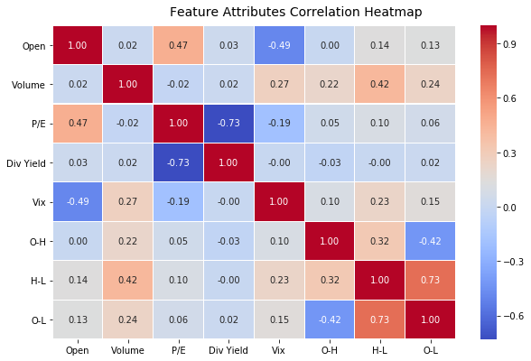

```python
# Check feature correlation after feature engineering
vs.heatmap(features_train)
display(features_train[['Open','H-L','Volume','Vix']].describe())
```

# Transforming Skewed Continuous Features

A dataset may sometimes contain at least one feature whose values tend to lie near a single number, but will also have a non-trivial number of vastly larger or smaller values than that single number. Algorithms can be sensitive to such distributions of values and can underperform if the range is not properly normalized.

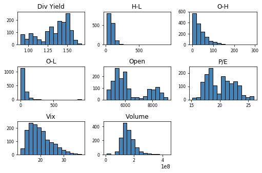

```python
# check features for skewness using histogram
vs.histogram(features_train)
```

```python
# funtion for log transformation of skewed features
def skew(df,skewed):
    features_log_transformed = pd.DataFrame(data=df)
    features_log_transformed[skewed] = df[skewed].apply(lambda x:np.log(x+1))
    return features_log_transformed

skewed = ['Open','Volume','P/E','Div Yield','Vix','O-H','H-L','O-L']


features_train_log_transformed = skew(features_train,skewed)
features_test_log_transformed = skew(features_test,skewed)
#vs.histogram(features_train_log_transformed)
#display(features_train_log_transformed.head())
```

# Normalizing Numerical Features

```python
# Function for normalizing and denormalizing of data using df/df[1] method
def normalize(data,row):
    data = data/row
    return data

def denormalize(data,row):
    data = data*row
    return data

feature_scale = features_train_log_transformed.iloc[0,:]
prices_scale = prices.iloc[0]
features_train_normal = normalize(features_train_log_transformed,feature_scale)
features_test_normal = normalize(features_test_log_transformed,feature_scale)
prices_train_normal = normalize(prices,prices_scale)
prices_test_normal = normalize(prices_test,prices_scale)
#display(features_train_normal.head())
#display(features_test_normal.head())
#display(prices_train_normal.head())
#display(prices_test_normal.head())
#type(prices_test)
```

# Split & Convert Data

```python
# Split data into training and testing set
# and Convert into numpy arrays
X_train = features_train_normal.values
X_test = features_test_normal.values
y_train = prices_train_normal.values
y_test = prices_test_normal.values
type(X_train)
```

```
numpy.ndarray
```

# Evaluating Model Performance

It is difficult to measure the quality of a given model without quantifying its performance over training and testing. This is typically done using some type of performance metric, whether it is through calculating some type of error, the goodness of fit, or some other useful measurement. For this project, we will be calculating the RMSE error and coefficient of determination, R2, to quantify model's performance.

```python
from sklearn.metrics import r2_score, mean_squared_error

# function for model evaluation using RMSE error and R2 score
def performance_metric(y_true,y_pred):
    score = r2_score(y_true,y_pred)
    error = mean_squared_error(y_true,y_pred)
    return np.sqrt(error),score
```

# Creating a benchmark model

## Benchmark Model : Linear Regression

```python
from sklearn.linear_model import LinearRegression
global SEED
SEED = 42

# function for training and predicting LinearRegression Model
def lr_predict(base_model):
    base_model.fit(X_train,y_train)
    lrtest = base_model.predict(X_test)
    lrtrain = base_model.predict(X_train)
    return lrtrain, lrtest

# function for plotting actual and predicted prices
def model_plot(df,title):

    df1 = pd.DataFrame(data=prices_test)
    df1['Pred'] = df
    fig = plt.figure(figsize=(28,12))
    plt.plot(df1['Close'],color='black')
    plt.plot(df1['Pred'],color='blue')
    plt.xlabel('Date',fontsize=(20))
    plt.ylabel('Prices',fontsize=(20))
    plt.title(title,fontsize=(30))
    plt.legend(["Actual","Prediction"],fontsize=(20))
    plt.show()
```

```
LinearRegression Model has RMSE Testing error of 138.70
LinearRegression Model has R2 score of 0.94
```

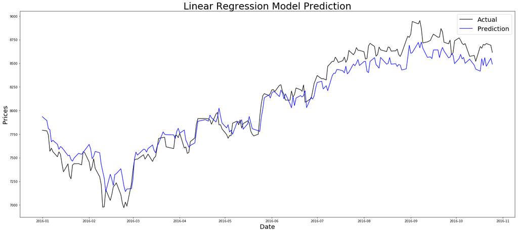

```python
# Implement Linear Regression Model
lrmodel = LinearRegression()
lrtrain,lrtest = lr_predict(lrmodel)
lrtestden = denormalize(lrtest,prices_scale)
rmse,score = performance_metric(prices_test,lrtestden)
print("{} Model has RMSE Testing error of {:.2f}".format(lrmodel.__class__.__name__,rmse))
print("{} Model has R2 score of {:.2f}".format(lrmodel.__class__.__name__,score))
model_plot(lrtestden,'Linear Regression Model Prediction')
```

# Model 1: Stacking of Learners

```python
from sklearn.svm import LinearSVR
from sklearn.tree import DecisionTreeRegressor
from keras.models import Sequential
from keras.layers.core import Dense,Activation,Dropout
from keras.layers.recurrent import LSTM
from xgboost import XGBRegressor
from sklearn.ensemble import  GradientBoostingRegressor
from sklearn.ensemble import  RandomForestRegressor
from sklearn.ensemble import AdaBoostRegressor
from sklearn.ensemble import ExtraTreesRegressor
from sklearn.model_selection import TimeSeriesSplit
from sklearn.model_selection import GridSearchCV
from sklearn.metrics import make_scorer
```

```python
# train and predict models using GridSearchCV

def base_model_predict(model,params):
    scorer = make_scorer(mean_squared_error)
    tscv = TimeSeriesSplit(n_splits=5)
    tscv = tscv.split(range(X_train.shape[0]))
    grid_obj = GridSearchCV(model,params,scorer,cv=tscv)
    grid_fit = grid_obj.fit(X_train,y_train)
    best_reg = grid_fit.best_estimator_
    ypred = best_reg.predict(X_test)
    ytrain = best_reg.predict(X_train)
    return best_reg, ytrain, ypred
```

### Base Model 1: AdaBoost Regressor

```python
adareginit = AdaBoostRegressor(random_state=SEED)
adaparamsinit = {}
adaregmodelinit,adatraininit,adatestinit = base_model_predict(adareginit,adaparamsinit)
adatestdeninit = denormalize(adatestinit,prices_scale)
adaerrorinit,adascoreinit = performance_metric(prices_test,adatestdeninit)
print("{} has Unoptimized Testing RMSE error of {:.2f}".format(adareginit.__class__.__name__,adaerrorinit))
print("{} has Unoptimized R2 score of {:.2f}".format(adareginit.__class__.__name__,adascoreinit))
```

```
AdaBoostRegressor has Unoptimized Testing RMSE error of 122.15
AdaBoostRegressor has Unoptimized R2 score of 0.95
```

```
AdaBoostRegressor has Testing RMSE error of 97.82
AdaBoostRegressor has R2 score of 0.97
```

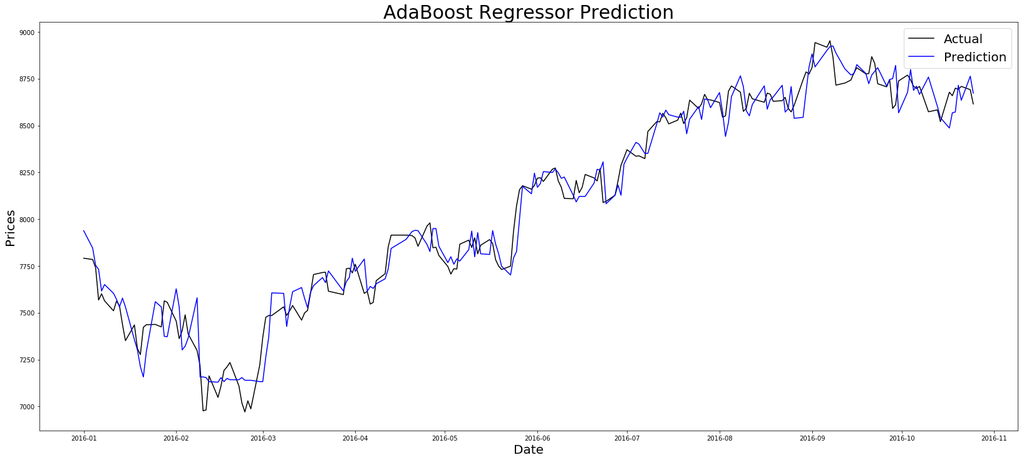

```python
adareg = AdaBoostRegressor(base_estimator=DecisionTreeRegressor(),random_state=42)
# parameters already tuned using Gridsearchcv
adaparams = {'n_estimators':[50],'learning_rate':[0.01],'base_estimator__max_depth':[10],'base_estimator__min_samples_split':[7]}
adaregmodel,adatrain,adatest = base_model_predict(adareg,adaparams)
adatestden = denormalize(adatest,prices_scale)
adaerror,adascore = performance_metric(prices_test,adatestden)
print("{} has Testing RMSE error of {:.2f}".format(adareg.__class__.__name__,adaerror))
print("{} has R2 score of {:.2f}".format(adareg.__class__.__name__,adascore))
adaooftrain = adatrain.reshape(-1,1)
adaooftest = adatest.reshape(-1,1)
model_plot(adatestden,'AdaBoost Regressor Prediction')
```

### Base Model 2: Gradient Boosting Regressor

```python
gbreginit = GradientBoostingRegressor(random_state=42)
gbparamsinit = {'n_estimators':[30]}
gbregmodelinit,gbtraininit,gbtestinit = base_model_predict(gbreginit,gbparamsinit)
gbtestdeninit = denormalize(gbtestinit,prices_scale)
gberrorinit,gbscoreinit = performance_metric(prices_test,gbtestdeninit)
print("{} has Unoptimized RMSE Testing error of {:.2f}".format(gbreginit.__class__.__name__,gberrorinit))
print("{} has Unoptimized R2 score of {:.2f}".format(gbreginit.__class__.__name__,gbscoreinit))
```

```
GradientBoostingRegressor has Unoptimized RMSE Testing error of 132.97
GradientBoostingRegressor has Unoptimized R2 score of 0.94
```

```
GradientBoostingRegressor has Testing RMSE error of 98.24
GradientBoostingRegressor has R2 score of 0.97
```

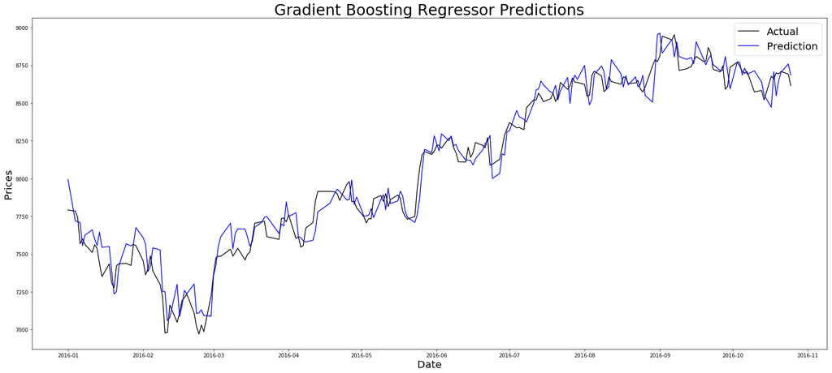

```python
gbreg = GradientBoostingRegressor(random_state=42)
# parameters already tuned using Gridsearchcv
gbparams = {'n_estimators':[100],'learning_rate':[0.3],'max_depth':[3],'alpha':[0.9],'min_samples_split':[5]}
gbregmodel,gbtrain,gbtest = base_model_predict(gbreg,gbparams)
gbtestden = denormalize(gbtest,prices_scale)
gberror,gbscore = performance_metric(prices_test,gbtestden)
print("{} has Testing RMSE error of {:.2f}".format(gbreg.__class__.__name__,gberror))
print("{} has R2 score of {:.2f}".format(gbreg.__class__.__name__,gbscore))
gbooftrain = gbtrain.reshape(-1,1)
gbooftest = gbtest.reshape(-1,1)
model_plot(gbtestden,'Gradient Boosting Regressor Predictions')
```

### Base Model 3: Extra Trees Regressor

```python
etreginit = ExtraTreesRegressor(random_state=42)
etparamsinit = {'n_estimators':[10],'max_depth':[5]}
etregmodelinit,ettraininit,ettestinit = base_model_predict(etreginit,etparamsinit)
ettestdeninit = denormalize(ettestinit,prices_scale)
eterrorinit,etscoreinit = performance_metric(prices_test,ettestdeninit)
print("{} has Unoptimized RMSE Testing error of {:.2f}".format(etreginit.__class__.__name__,eterrorinit))
print("{} has Unoptimized R2 score of {:.2f}".format(etreginit.__class__.__name__,etscoreinit))
```

```
ExtraTreesRegressor has Unoptimized RMSE Testing error of 150.08
ExtraTreesRegressor has Unoptimized R2 score of 0.92
```

```
ExtraTreesRegressor has Testing RMSE error of 99.32
ExtraTreesRegressor has R2 score of 0.97
```

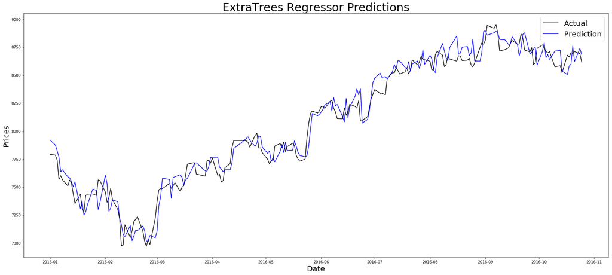

```python
etreg = ExtraTreesRegressor(random_state=42)
# parameters already tuned using Gridsearchcv
etparams = {'n_estimators':[10],'max_depth':[10],'min_samples_split':[2]}
etregmodel,ettrain,ettest = base_model_predict(etreg,etparams)
ettestden = denormalize(ettest,prices_scale)
eterror,etscore = performance_metric(prices_test,ettestden)
print("{} has Testing RMSE error of {:.2f}".format(etreg.__class__.__name__,eterror))
print("{} has R2 score of {:.2f}".format(etreg.__class__.__name__,etscore))
etooftrain = ettrain.reshape(-1,1)
etooftest = ettest.reshape(-1,1)
model_plot(ettestden,'ExtraTrees Regressor Predictions')
```

### Base Model 4: Random Forest Regressor

```python
rfreginit = RandomForestRegressor(random_state=42)
rfparamsinit = {'n_estimators':[10],'max_depth':[5]}
rfregmodelinit,rftraininit,rftestinit = base_model_predict(rfreginit,rfparamsinit)
rftestdeninit = denormalize(rftestinit,prices_scale)
rferrorinit,rfscoreinit = performance_metric(prices_test,rftestdeninit)
print("{} has Unoptimized Testing RMSE error of {:.2f}".format(rfreginit.__class__.__name__,rferrorinit))
print("{} has Unoptimized R2 score of {:.2f}".format(rfreginit.__class__.__name__,rfscoreinit))
```

```
RandomForestRegressor has Unoptimized Testing RMSE error of 102.10
RandomForestRegressor has Unoptimized R2 score of 0.97
```

```
RandomForestRegressor has Testing RMSE error of 97.43
RandomForestRegressor has R2 score of 0.97
```

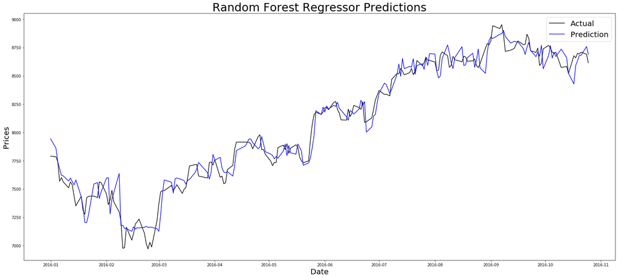

```python
rfreg = RandomForestRegressor(random_state=42)
# parameters already tuned using Gridsearchcv
rfparams = {'n_estimators':[10],'max_depth':[10],'min_samples_split':[2]}
rfregmodel,rftrain,rftest = base_model_predict(rfreg,rfparams)
rftestden = denormalize(rftest,prices_scale)
rferror,rfscore = performance_metric(prices_test,rftestden)
print("{} has Testing RMSE error of {:.2f}".format(rfreg.__class__.__name__,rferror))
print("{} has R2 score of {:.2f}".format(rfreg.__class__.__name__,rfscore))
rfooftrain = rftrain.reshape(-1,1)
rfooftest = rftest.reshape(-1,1)
model_plot(rftestden,'Random Forest Regressor Predictions')
```

### Base Model 5: LinearSVM Regressor

```python
lsvrreginit = LinearSVR(random_state=SEED)
lsvrparamsinit = {'C':[1],'tol':[0.01],'max_iter':[2000],'loss':['epsilon_insensitive']}
lsvrregmodelinit,lsvrtraininit,lsvrtestinit = base_model_predict(lsvrreginit,lsvrparamsinit)
lsvrtestdeninit = denormalize(lsvrtestinit,prices_scale)
lsvrerrorinit,lsvrscoreinit = performance_metric(prices_test,lsvrtestdeninit)
print("{} has Unoptimized Testing RMSE error of {:.2f}".format(lsvrreginit.__class__.__name__,lsvrerrorinit))
print("{} has Unoptimized R2 score of {:.2f}".format(lsvrreginit.__class__.__name__,lsvrscoreinit))
```

```
LinearSVR has Unoptimized Testing RMSE error of 289.23
LinearSVR has Unoptimized R2 score of 0.72
```

```
LinearSVR has Testing RMSE error of 149.56
LinearSVR has R2 score of 0.92
```

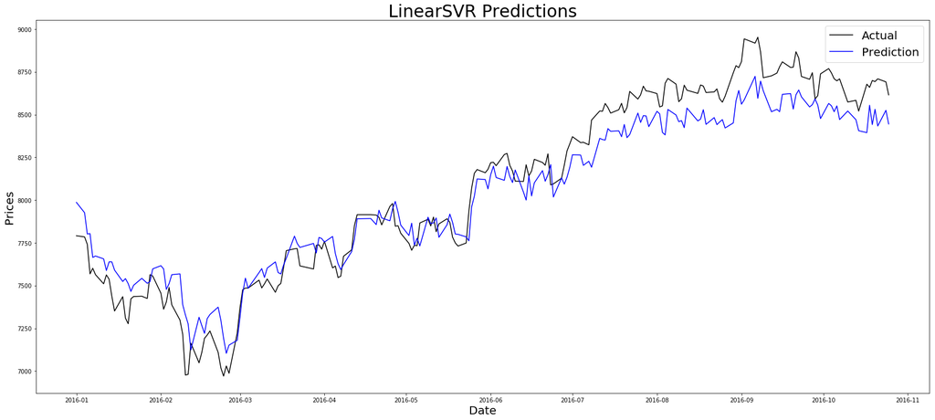

```python
from sklearn.svm import LinearSVR
lsvrreg = LinearSVR(random_state=SEED)
lsvrparams = {'C':[2],'tol':[0.07],'max_iter':[1000],'loss':['epsilon_insensitive']}
lsvrregmodel,lsvrtrain,lsvrtest = base_model_predict(lsvrreg,lsvrparams)
lsvrtestden = denormalize(lsvrtest,prices_scale)
lsvrerror,lsvrscore = performance_metric(prices_test,lsvrtestden)
print("{} has Testing RMSE error of {:.2f}".format(lsvrreg.__class__.__name__,lsvrerror))
print("{} has R2 score of {:.2f}".format(lsvrreg.__class__.__name__,lsvrscore))
lsvrooftrain = lsvrtrain.reshape(-1,1)
lsvrooftest = lsvrtest.reshape(-1,1)
model_plot(lsvrtestden,'LinearSVR Predictions')
```

### Creating Train and test features for Stacker using first level predictions

```python
base_predictions_train = pd.DataFrame( {'ExtraTrees': etooftrain.ravel(), 'RandomForest': rfooftrain.ravel(),
     'AdaBoost': adaooftrain.ravel(), 'GradientBoost': gbooftrain.ravel(),'LinearSVR': lsvrooftrain.ravel()})
x_train = np.concatenate(( etooftrain, rfooftrain, adaooftrain, gbooftrain, lsvrooftrain), axis=1)
x_test = np.concatenate(( etooftest, rfooftest, adaooftest, gbooftest, lsvrooftest), axis=1)
display(base_predictions_train.head())
```

|  | ExtraTrees | RandomForest | AdaBoost | GradientBoost | LinearSVR |
| --- | --- | --- | --- | --- | --- |
| 0 | 0.995695 | 0.992393 | 0.998723 | 0.994417 | 0.993150 |
| 1 | 0.996531 | 0.996717 | 0.994888 | 1.000850 | 0.998669 |
| 2 | 1.001608 | 1.002346 | 0.999433 | 0.997287 | 1.008039 |
| 3 | 0.996197 | 0.997888 | 0.994522 | 0.994159 | 1.005419 |
| 4 | 0.993087 | 0.993445 | 0.992494 | 0.994461 | 0.997405 |

# Stacker Model: XGB Regressor

```python
def xgb_model_predict(model,params):
    scorer = make_scorer(mean_squared_error)
    tscv = TimeSeriesSplit(n_splits=5)
    tscv = tscv.split(range(X_train.shape[0]))
    grid_obj = GridSearchCV(model,params,scorer,cv=tscv)
    grid_fit = grid_obj.fit(x_train,y_train)
    best_reg = grid_fit.best_estimator_
    ypred = best_reg.predict(x_test[:200,])
    ytrain = best_reg.predict(x_train)
    return best_reg, ytrain, ypred
```

```
XGBRegressor has Testing error of 95.97
XGBRegressor has R2 score of 0.97
```

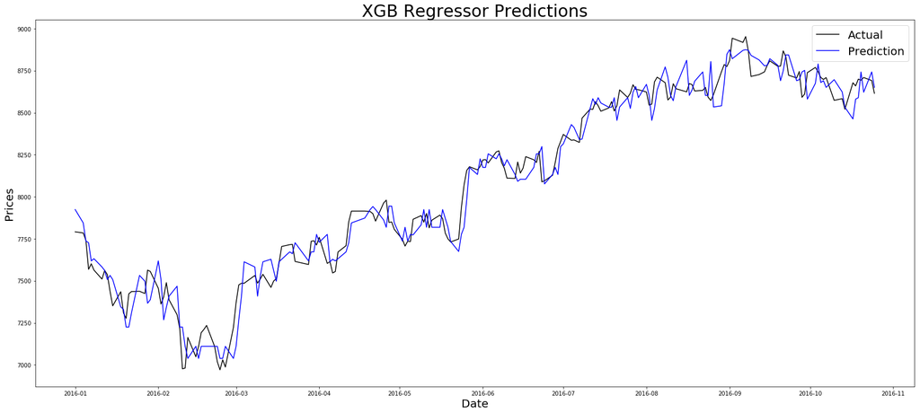

```python
xgbreg = XGBRegressor()
# parameters already tuned using Gridsearchcv
xgbparams = {'n_estimators':[100],'learning_rate':[0.07],
             'gamma':[0.0009],'max_depth':[3],'random_state':[SEED]}
xgbregmodel,xgbtrain,xgbtest = xgb_model_predict(xgbreg,xgbparams)
xgbtestden = denormalize(xgbtest,prices_scale)
xgberror,xgbscore = performance_metric(prices_test[:200,],xgbtestden)
print("{} has Testing error of {:.2f}".format(xgbreg.__class__.__name__,xgberror))
print("{} has R2 score of {:.2f}".format(xgbreg.__class__.__name__,xgbscore))
model_plot(xgbtestden, 'XGB Regressor Predictions')
```

As can be seen from above plot, predictions very closely resembles the actual price trend.

## Test XGB Regressor on different folds of Test set for robustness

```python
# fold 1 of test set
xtest1 = x_test[0:150,]

# fold 2 of test set
xtest2 = x_test[0:180,]

# fold 3 of test set
xtest3 = x_test[0:200,]
```

```python
# Evaluating xgb regressor on different test data
for i,fold in enumerate([xtest1,xtest2,xtest3]):
    size = len(fold)
    y_pred = xgbregmodel.predict(fold)
    xgbfoldden = denormalize(y_pred,prices_scale)
    folderror,foldscore = performance_metric(prices_test[:size],xgbfoldden)
    print("On test fold {} {} has Testing error of {:.2f}".format(i+1,xgbregmodel.__class__.__name__,folderror))
    print("On test fold {} {} has R2 score of {:.2f}".format(i+1,xgbregmodel.__class__.__name__,foldscore))
```

```
On test fold 1 XGBRegressor has Testing error of 96.09
On test fold 1 XGBRegressor has R2 score of 0.96
On test fold 2 XGBRegressor has Testing error of 96.07
On test fold 2 XGBRegressor has R2 score of 0.97
On test fold 3 XGBRegressor has Testing error of 95.97
On test fold 3 XGBRegressor has R2 score of 0.97
```

# MLP

```python
from keras.models import Sequential
from keras.layers.core import Dense,Activation
from keras.optimizers import rmsprop
from keras.utils import np_utils
```

```python
# Implement MLP using keras sequential model
model_mlp = Sequential()
model_mlp.add(Dense(20,activation='relu',input_shape=(8,)))
model_mlp.add(Dense(1, activation='relu'))

model_mlp.compile(loss='mean_squared_error',optimizer='rmsprop',metrics=['mse'])
model_mlp.summary()
```

```
_________________________________________________________________
Layer (type)                 Output Shape              Param #
=================================================================
dense_1 (Dense)              (None, 20)                180
_________________________________________________________________
dense_2 (Dense)              (None, 1)                 21
=================================================================
Total params: 201
Trainable params: 201
Non-trainable params: 0
_________________________________________________________________
```

```python
model_mlp.fit(X_train, y_train,epochs=50,batch_size=71,verbose=0)
```

```
<keras.callbacks.History at 0x7fc1aa5c2710>
```

```python
mlp_pred = model_mlp.predict(X_test)
mlp_predden = denormalize(mlp_pred,prices_scale)
mlperror,mlpscore = performance_metric(prices_test,mlp_predden)
print("MLP Model has a Testing RMSE error of {:.2f}".format(mlperror))
print("MLP Model has a R2 score of {:.2f}".format(mlpscore))
```

```
MLP Model has a Testing RMSE error of 133.38
MLP Model has a R2 score of 0.94
```

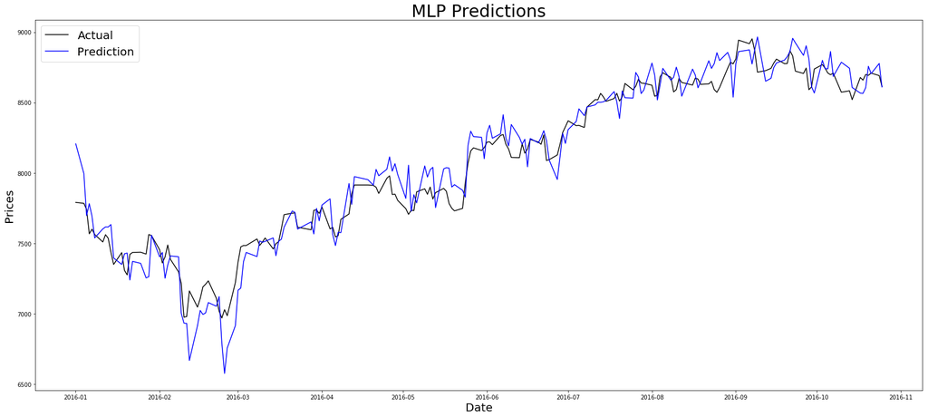

```python
model_plot(mlp_predden, 'MLP Predictions')
```

As can be seen from figure that our model predict price trends very well but it still have to tuned more aggressively in order to make forecasts more accurate

# Model Evaluation

```python
# Evaluate all models on RMSE error and R2 score and pick the best one

clf = ['XGB','GradientBoosting','RandomForest', 'ExtraTrees', 'AdaBoost', 'LinearSVR', 'MLP']
rmseerror = [xgberror,gberror,rferror,eterror,adaerror,lsvrerror,mlperror]
r2score = [xgbscore,gbscore,rfscore,etscore,adascore,lsvrscore,mlpscore]
eval_metric = pd.DataFrame(index=clf)
eval_metric['RMSE Testing Error'] = np.around(rmseerror,decimals=2)
eval_metric['R2 Score ( % )'] = np.around(r2score,decimals=4)*100
display(eval_metric)
```

|  | RMSE Testing Error | R2 Score ( % ) |
| --- | --- | --- |
| XGB | 95.97 | 96.91 |
| GradientBoosting | 98.24 | 96.76 |
| RandomForest | 97.43 | 96.82 |
| ExtraTrees | 99.32 | 96.69 |
| AdaBoost | 97.82 | 96.79 |
| LinearSVR | 149.56 | 92.50 |
| MLP | 133.38 | 94.03 |

# Conclusion:

As per our evaluation metric as shown above in Table 6, XGBoost Regressor performs better than both benchmark model and comparator model by significant margin on both RMSE error and R2 score. This is because XGB Regressor is used as a stacker which uses predictions from several base models thereby improving on the errors made by these models. These base models might have picked up different characteristics of the dataset while training which helps the final stacker in generalizing well over unseen data and improve overall accuracy of the system.